# SQ complex

## Shared Qs (complex)

#### Question

1. Let $z_1$ and $z_2$ be two [complex numbers](https://en.wikipedia.org/wiki/Complex_number).
   $$z_1 = -4-i$$
   $$z_2 = 1+3i$$
   Find the sum.
   $$z_1+z_2 = ~?$$

   *Type your answer precisely, with no spaces, using digits, “-”, “+”, and “i”. If the real term is nonzero, put it first. If either component is zero, do not include that term. If both components are zero, type “0” without the quotes. Instead of writing “1i” or “-1i” just write “i” or “-i”.*

#### Solution

#### Question

2. Let $z_1$ and $z_2$ be two [complex numbers](https://en.wikipedia.org/wiki/Complex_number).
   $$z_1 = 8-5i$$
   $$z_2 = 2-7i$$
   Find the sum.
   $$z_1+z_2 = ~?$$

   *Type your answer precisely, with no spaces, using digits, “-”, “+”, and “i”. If the real term is nonzero, put it first. If either component is zero, do not include that term. If both components are zero, type “0” without the quotes. Instead of writing “1i” or “-1i” just write “i” or “-i”.*

#### Solution

#### Question

3. Let $z_1$ and $z_2$ be two [complex numbers](https://en.wikipedia.org/wiki/Complex_number).
   $$z_1 = 7+7i$$
   $$z_2 = -2-9i$$
   Find the sum.
   $$z_1+z_2 = ~?$$

   *Type your answer precisely, with no spaces, using digits, “-”, “+”, and “i”. If the real term is nonzero, put it first. If either component is zero, do not include that term. If both components are zero, type “0” without the quotes. Instead of writing “1i” or “-1i” just write “i” or “-i”.*

#### Solution

#### Question

4. Let $z_1$ and $z_2$ be two [complex numbers](https://en.wikipedia.org/wiki/Complex_number).
   $$z_1 = -4+9i$$
   $$z_2 = 8+5i$$
   Find the sum.
   $$z_1+z_2 = ~?$$

   *Type your answer precisely, with no spaces, using digits, “-”, “+”, and “i”. If the real term is nonzero, put it first. If either component is zero, do not include that term. If both components are zero, type “0” without the quotes. Instead of writing “1i” or “-1i” just write “i” or “-i”.*

#### Solution

#### Question

5. Let $z_1$ and $z_2$ be two [complex numbers](https://en.wikipedia.org/wiki/Complex_number).
   $$z_1 = -6-9i$$
   $$z_2 = -4-i$$
   Find the sum.
   $$z_1+z_2 = ~?$$

   *Type your answer precisely, with no spaces, using digits, “-”, “+”, and “i”. If the real term is nonzero, put it first. If either component is zero, do not include that term. If both components are zero, type “0” without the quotes. Instead of writing “1i” or “-1i” just write “i” or “-i”.*

#### Solution

#### Question

6. Let $z_1$ and $z_2$ be two [complex numbers](https://en.wikipedia.org/wiki/Complex_number).
   $$z_1 = 2+7i$$
   $$z_2 = -9+9i$$
   Find the sum.
   $$z_1+z_2 = ~?$$

   *Type your answer precisely, with no spaces, using digits, “-”, “+”, and “i”. If the real term is nonzero, put it first. If either component is zero, do not include that term. If both components are zero, type “0” without the quotes. Instead of writing “1i” or “-1i” just write “i” or “-i”.*

#### Solution

#### Question

7. Let $z_1$ and $z_2$ be two [complex numbers](https://en.wikipedia.org/wiki/Complex_number).
   $$z_1 = -9+4i$$
   $$z_2 = 4-4i$$
   Find the sum.
   $$z_1+z_2 = ~?$$

   *Type your answer precisely, with no spaces, using digits, “-”, “+”, and “i”. If the real term is nonzero, put it first. If either component is zero, do not include that term. If both components are zero, type “0” without the quotes. Instead of writing “1i” or “-1i” just write “i” or “-i”.*

#### Solution

#### Question

8. Let $z_1$ and $z_2$ be two [complex numbers](https://en.wikipedia.org/wiki/Complex_number).
   $$z_1 = -8+6i$$
   $$z_2 = 9-2i$$
   Find the sum.
   $$z_1+z_2 = ~?$$

   *Type your answer precisely, with no spaces, using digits, “-”, “+”, and “i”. If the real term is nonzero, put it first. If either component is zero, do not include that term. If both components are zero, type “0” without the quotes. Instead of writing “1i” or “-1i” just write “i” or “-i”.*

#### Solution

#### Question

9. Let $z_1$ and $z_2$ be two [complex numbers](https://en.wikipedia.org/wiki/Complex_number).
   $$z_1 = 2+i$$
   $$z_2 = -3+2i$$
   Find the sum.
   $$z_1+z_2 = ~?$$

   *Type your answer precisely, with no spaces, using digits, “-”, “+”, and “i”. If the real term is nonzero, put it first. If either component is zero, do not include that term. If both components are zero, type “0” without the quotes. Instead of writing “1i” or “-1i” just write “i” or “-i”.*

#### Solution

#### Question

10. Let $z_1$ and $z_2$ be two [complex numbers](https://en.wikipedia.org/wiki/Complex_number).
    $$z_1 = 4+9i$$
    $$z_2 = 8-7i$$
    Find the sum.
    $$z_1+z_2 = ~?$$

    *Type your answer precisely, with no spaces, using digits, “-”, “+”, and “i”. If the real term is nonzero, put it first. If either component is zero, do not include that term. If both components are zero, type “0” without the quotes. Instead of writing “1i” or “-1i” just write “i” or “-i”.*

#### Solution

#### Question

11. Let $z_1$ and $z_2$ be two [complex numbers](https://en.wikipedia.org/wiki/Complex_number).
    $$z_1 = 7-i$$
    $$z_2 = 2-7i$$
    Find the difference.
    $$z_2-z_1 = ~?$$

    *Type your answer precisely, with no spaces, using digits, “-”, “+”, and “i”. If the real term is nonzero, put it first. If either component is zero, do not include that term. If both components are zero, type “0” without the quotes. Instead of writing “1i” or “-1i” just write “i” or “-i”.*

#### Solution

#### Question

12. Let $z_1$ and $z_2$ be two [complex numbers](https://en.wikipedia.org/wiki/Complex_number).
    $$z_1 = 1+3i$$
    $$z_2 = 5+4i$$
    Find the difference.
    $$z_2-z_1 = ~?$$

    *Type your answer precisely, with no spaces, using digits, “-”, “+”, and “i”. If the real term is nonzero, put it first. If either component is zero, do not include that term. If both components are zero, type “0” without the quotes. Instead of writing “1i” or “-1i” just write “i” or “-i”.*

#### Solution

#### Question

13. Let $z_1$ and $z_2$ be two [complex numbers](https://en.wikipedia.org/wiki/Complex_number).
    $$z_1 = 8-8i$$
    $$z_2 = 7-4i$$
    Find the difference.
    $$z_2-z_1 = ~?$$

    *Type your answer precisely, with no spaces, using digits, “-”, “+”, and “i”. If the real term is nonzero, put it first. If either component is zero, do not include that term. If both components are zero, type “0” without the quotes. Instead of writing “1i” or “-1i” just write “i” or “-i”.*

#### Solution

#### Question

14. Let $z_1$ and $z_2$ be two [complex numbers](https://en.wikipedia.org/wiki/Complex_number).
    $$z_1 = -2-3i$$
    $$z_2 = -2-6i$$
    Find the difference.
    $$z_1-z_2 = ~?$$

    *Type your answer precisely, with no spaces, using digits, “-”, “+”, and “i”. If the real term is nonzero, put it first. If either component is zero, do not include that term. If both components are zero, type “0” without the quotes. Instead of writing “1i” or “-1i” just write “i” or “-i”.*

#### Solution

#### Question

15. Let $z_1$ and $z_2$ be two [complex numbers](https://en.wikipedia.org/wiki/Complex_number).
    $$z_1 = -2-8i$$
    $$z_2 = 4+9i$$
    Find the difference.
    $$z_1-z_2 = ~?$$

    *Type your answer precisely, with no spaces, using digits, “-”, “+”, and “i”. If the real term is nonzero, put it first. If either component is zero, do not include that term. If both components are zero, type “0” without the quotes. Instead of writing “1i” or “-1i” just write “i” or “-i”.*

#### Solution

#### Question

16. Let $z_1$ and $z_2$ be two [complex numbers](https://en.wikipedia.org/wiki/Complex_number).
    $$z_1 = -5+8i$$
    $$z_2 = 6-4i$$
    Find the difference.
    $$z_1-z_2 = ~?$$

    *Type your answer precisely, with no spaces, using digits, “-”, “+”, and “i”. If the real term is nonzero, put it first. If either component is zero, do not include that term. If both components are zero, type “0” without the quotes. Instead of writing “1i” or “-1i” just write “i” or “-i”.*

#### Solution

#### Question

17. Let $z_1$ and $z_2$ be two [complex numbers](https://en.wikipedia.org/wiki/Complex_number).
    $$z_1 = 8+i$$
    $$z_2 = -1+i$$
    Find the difference.
    $$z_1-z_2 = ~?$$

    *Type your answer precisely, with no spaces, using digits, “-”, “+”, and “i”. If the real term is nonzero, put it first. If either component is zero, do not include that term. If both components are zero, type “0” without the quotes. Instead of writing “1i” or “-1i” just write “i” or “-i”.*

#### Solution

#### Question

18. Let $z_1$ and $z_2$ be two [complex numbers](https://en.wikipedia.org/wiki/Complex_number).
    $$z_1 = -3-8i$$
    $$z_2 = -1+7i$$
    Find the difference.
    $$z_2-z_1 = ~?$$

    *Type your answer precisely, with no spaces, using digits, “-”, “+”, and “i”. If the real term is nonzero, put it first. If either component is zero, do not include that term. If both components are zero, type “0” without the quotes. Instead of writing “1i” or “-1i” just write “i” or “-i”.*

#### Solution

#### Question

19. Let $z_1$ and $z_2$ be two [complex numbers](https://en.wikipedia.org/wiki/Complex_number).
    $$z_1 = -2+4i$$
    $$z_2 = 1+6i$$
    Find the difference.
    $$z_2-z_1 = ~?$$

    *Type your answer precisely, with no spaces, using digits, “-”, “+”, and “i”. If the real term is nonzero, put it first. If either component is zero, do not include that term. If both components are zero, type “0” without the quotes. Instead of writing “1i” or “-1i” just write “i” or “-i”.*

#### Solution

#### Question

20. Let $z_1$ and $z_2$ be two [complex numbers](https://en.wikipedia.org/wiki/Complex_number).
    $$z_1 = 5+4i$$
    $$z_2 = -4+2i$$
    Find the difference.
    $$z_1-z_2 = ~?$$

    *Type your answer precisely, with no spaces, using digits, “-”, “+”, and “i”. If the real term is nonzero, put it first. If either component is zero, do not include that term. If both components are zero, type “0” without the quotes. Instead of writing “1i” or “-1i” just write “i” or “-i”.*

#### Solution

#### Question

21. Let $z_1$ and $z_2$ be two [complex numbers](https://en.wikipedia.org/wiki/Complex_number).
    $$z_1 = -1-9i$$
    $$z_2 = -4+i$$
    Find the product.
    $$z_1 \cdot z_2 = ~?$$

    *Type your answer precisely, with no spaces, using digits, “-”, “+”, and “i”. If the real term is nonzero, put it first. If either component is zero, do not include that term. If both components are zero, type “0” without the quotes. Instead of writing “1i” or “-1i” just write “i” or “-i”.*

#### Solution

#### Question

22. Let $z_1$ and $z_2$ be two [complex numbers](https://en.wikipedia.org/wiki/Complex_number).
    $$z_1 = 6+3i$$
    $$z_2 = 7+i$$
    Find the product.
    $$z_1 \cdot z_2 = ~?$$

    *Type your answer precisely, with no spaces, using digits, “-”, “+”, and “i”. If the real term is nonzero, put it first. If either component is zero, do not include that term. If both components are zero, type “0” without the quotes. Instead of writing “1i” or “-1i” just write “i” or “-i”.*

#### Solution

#### Question

23. Let $z_1$ and $z_2$ be two [complex numbers](https://en.wikipedia.org/wiki/Complex_number).
    $$z_1 = 4-7i$$
    $$z_2 = -6+4i$$
    Find the product.
    $$z_1 \cdot z_2 = ~?$$

    *Type your answer precisely, with no spaces, using digits, “-”, “+”, and “i”. If the real term is nonzero, put it first. If either component is zero, do not include that term. If both components are zero, type “0” without the quotes. Instead of writing “1i” or “-1i” just write “i” or “-i”.*

#### Solution

#### Question

24. Let $z_1$ and $z_2$ be two [complex numbers](https://en.wikipedia.org/wiki/Complex_number).
    $$z_1 = -5-8i$$
    $$z_2 = 2+4i$$
    Find the product.
    $$z_1 \cdot z_2 = ~?$$

    *Type your answer precisely, with no spaces, using digits, “-”, “+”, and “i”. If the real term is nonzero, put it first. If either component is zero, do not include that term. If both components are zero, type “0” without the quotes. Instead of writing “1i” or “-1i” just write “i” or “-i”.*

#### Solution

#### Question

25. Let $z_1$ and $z_2$ be two [complex numbers](https://en.wikipedia.org/wiki/Complex_number).
    $$z_1 = -4-6i$$
    $$z_2 = 9+3i$$
    Find the product.
    $$z_1 \cdot z_2 = ~?$$

    *Type your answer precisely, with no spaces, using digits, “-”, “+”, and “i”. If the real term is nonzero, put it first. If either component is zero, do not include that term. If both components are zero, type “0” without the quotes. Instead of writing “1i” or “-1i” just write “i” or “-i”.*

#### Solution

#### Question

26. Let $z_1$ and $z_2$ be two [complex numbers](https://en.wikipedia.org/wiki/Complex_number).
    $$z_1 = 8-i$$
    $$z_2 = 5-8i$$
    Find the product.
    $$z_1 \cdot z_2 = ~?$$

    *Type your answer precisely, with no spaces, using digits, “-”, “+”, and “i”. If the real term is nonzero, put it first. If either component is zero, do not include that term. If both components are zero, type “0” without the quotes. Instead of writing “1i” or “-1i” just write “i” or “-i”.*

#### Solution

#### Question

27. Let $z_1$ and $z_2$ be two [complex numbers](https://en.wikipedia.org/wiki/Complex_number).
    $$z_1 = -2-2i$$
    $$z_2 = 2-8i$$
    Find the product.
    $$z_1 \cdot z_2 = ~?$$

    *Type your answer precisely, with no spaces, using digits, “-”, “+”, and “i”. If the real term is nonzero, put it first. If either component is zero, do not include that term. If both components are zero, type “0” without the quotes. Instead of writing “1i” or “-1i” just write “i” or “-i”.*

#### Solution

#### Question

28. Let $z_1$ and $z_2$ be two [complex numbers](https://en.wikipedia.org/wiki/Complex_number).
    $$z_1 = -7+i$$
    $$z_2 = 9-8i$$
    Find the product.
    $$z_1 \cdot z_2 = ~?$$

    *Type your answer precisely, with no spaces, using digits, “-”, “+”, and “i”. If the real term is nonzero, put it first. If either component is zero, do not include that term. If both components are zero, type “0” without the quotes. Instead of writing “1i” or “-1i” just write “i” or “-i”.*

#### Solution

#### Question

29. Let $z_1$ and $z_2$ be two [complex numbers](https://en.wikipedia.org/wiki/Complex_number).
    $$z_1 = 5-4i$$
    $$z_2 = -7-2i$$
    Find the product.
    $$z_1 \cdot z_2 = ~?$$

    *Type your answer precisely, with no spaces, using digits, “-”, “+”, and “i”. If the real term is nonzero, put it first. If either component is zero, do not include that term. If both components are zero, type “0” without the quotes. Instead of writing “1i” or “-1i” just write “i” or “-i”.*

#### Solution

#### Question

30. Let $z_1$ and $z_2$ be two [complex numbers](https://en.wikipedia.org/wiki/Complex_number).
    $$z_1 = 4-2i$$
    $$z_2 = -2-8i$$
    Find the product.
    $$z_1 \cdot z_2 = ~?$$

    *Type your answer precisely, with no spaces, using digits, “-”, “+”, and “i”. If the real term is nonzero, put it first. If either component is zero, do not include that term. If both components are zero, type “0” without the quotes. Instead of writing “1i” or “-1i” just write “i” or “-i”.*

#### Solution

#### Question

31. Let $z_1$ be a complex number with integer components. It is graphed on a [complex plane](https://en.wikipedia.org/wiki/Complex_plane) below.

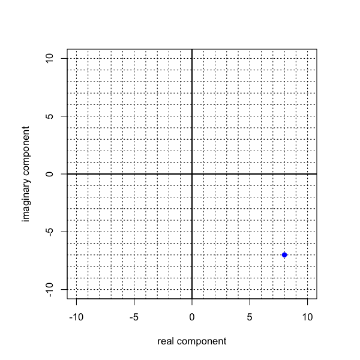

    Please **write the value of $z_1$** (in rectangular form: $a+bi$).

    *Type your answer precisely, with no spaces, using digits, “-”, “+”, and “i”. If the real term is nonzero, put it first. If either component is zero, do not include that term. If both components are zero, type “0” without the quotes. Instead of writing “1i” or “-1i” just write “i” or “-i”.*

#### Solution

#### Question

32. Let $z_1$ be a complex number with integer components. It is graphed on a [complex plane](https://en.wikipedia.org/wiki/Complex_plane) below.

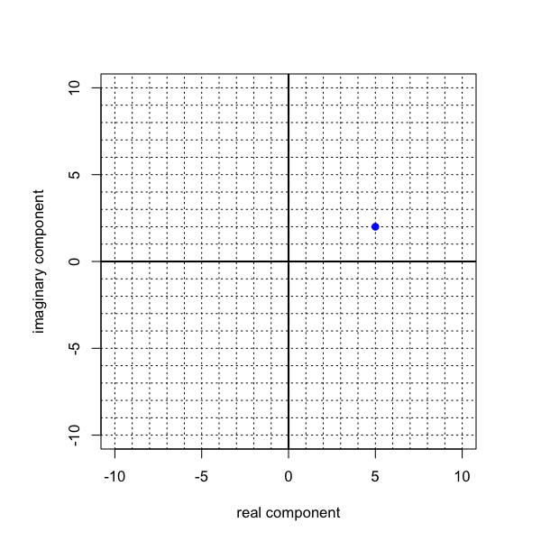

    Please **write the value of $z_1$** (in rectangular form: $a+bi$).

    *Type your answer precisely, with no spaces, using digits, “-”, “+”, and “i”. If the real term is nonzero, put it first. If either component is zero, do not include that term. If both components are zero, type “0” without the quotes. Instead of writing “1i” or “-1i” just write “i” or “-i”.*

#### Solution

#### Question

33. Let $z_1$ be a complex number with integer components. It is graphed on a [complex plane](https://en.wikipedia.org/wiki/Complex_plane) below.

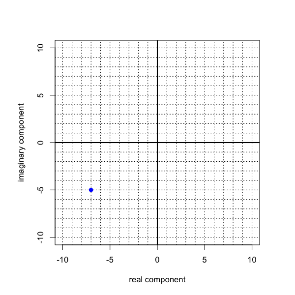

    Please **write the value of $z_1$** (in rectangular form: $a+bi$).

    *Type your answer precisely, with no spaces, using digits, “-”, “+”, and “i”. If the real term is nonzero, put it first. If either component is zero, do not include that term. If both components are zero, type “0” without the quotes. Instead of writing “1i” or “-1i” just write “i” or “-i”.*

#### Solution

#### Question

34. Let $z_1$ be a complex number with integer components. It is graphed on a [complex plane](https://en.wikipedia.org/wiki/Complex_plane) below.

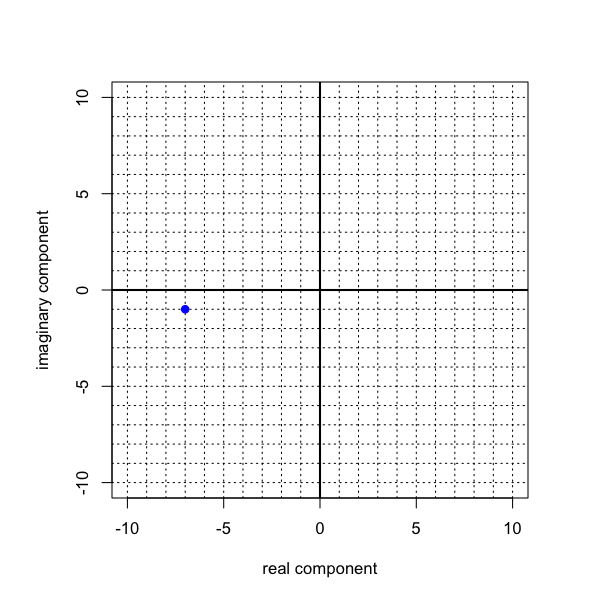

    Please **write the value of $z_1$** (in rectangular form: $a+bi$).

    *Type your answer precisely, with no spaces, using digits, “-”, “+”, and “i”. If the real term is nonzero, put it first. If either component is zero, do not include that term. If both components are zero, type “0” without the quotes. Instead of writing “1i” or “-1i” just write “i” or “-i”.*

#### Solution

#### Question

35. Let $z_1$ be a complex number with integer components. It is graphed on a [complex plane](https://en.wikipedia.org/wiki/Complex_plane) below.

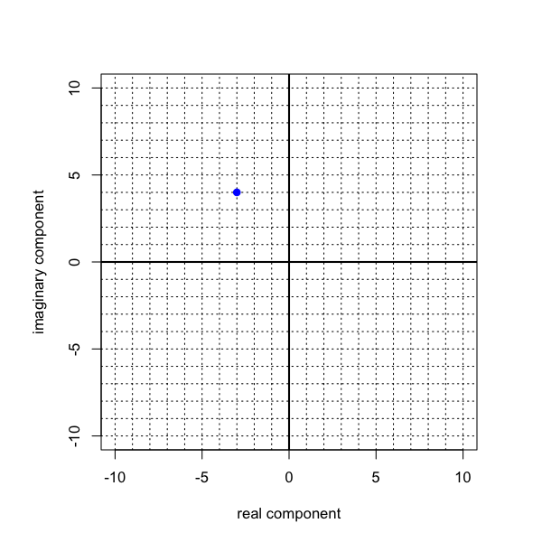

    Please **write the value of $z_1$** (in rectangular form: $a+bi$).

    *Type your answer precisely, with no spaces, using digits, “-”, “+”, and “i”. If the real term is nonzero, put it first. If either component is zero, do not include that term. If both components are zero, type “0” without the quotes. Instead of writing “1i” or “-1i” just write “i” or “-i”.*

#### Solution

#### Question

36. Let $z_1$ be a complex number with integer components. It is graphed on a [complex plane](https://en.wikipedia.org/wiki/Complex_plane) below.

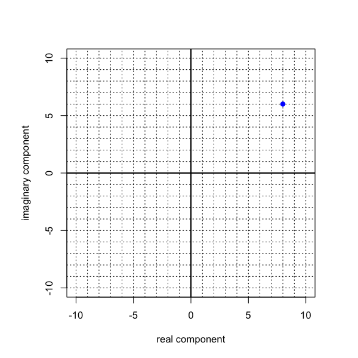

    Please **write the value of $z_1$** (in rectangular form: $a+bi$).

    *Type your answer precisely, with no spaces, using digits, “-”, “+”, and “i”. If the real term is nonzero, put it first. If either component is zero, do not include that term. If both components are zero, type “0” without the quotes. Instead of writing “1i” or “-1i” just write “i” or “-i”.*

#### Solution

#### Question

37. Let $z_1$ be a complex number with integer components. It is graphed on a [complex plane](https://en.wikipedia.org/wiki/Complex_plane) below.

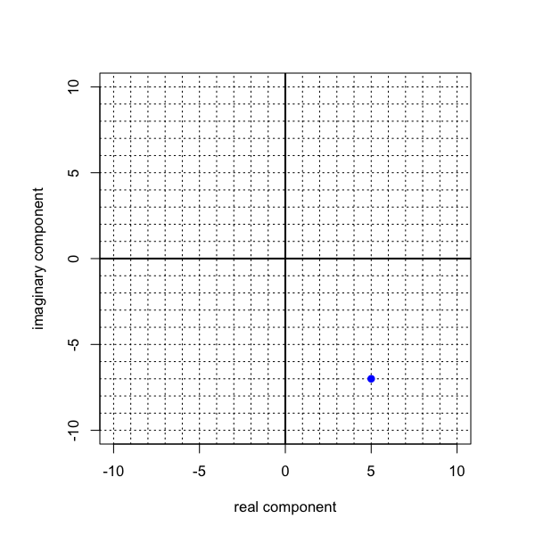

    Please **write the value of $z_1$** (in rectangular form: $a+bi$).

    *Type your answer precisely, with no spaces, using digits, “-”, “+”, and “i”. If the real term is nonzero, put it first. If either component is zero, do not include that term. If both components are zero, type “0” without the quotes. Instead of writing “1i” or “-1i” just write “i” or “-i”.*

#### Solution

#### Question

38. Let $z_1$ be a complex number with integer components. It is graphed on a [complex plane](https://en.wikipedia.org/wiki/Complex_plane) below.

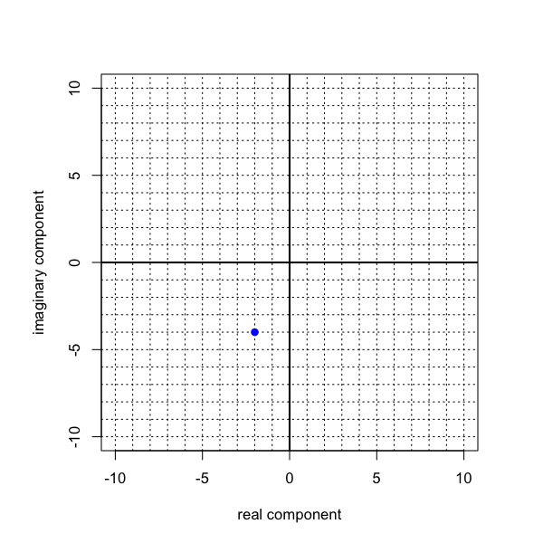

    Please **write the value of $z_1$** (in rectangular form: $a+bi$).

    *Type your answer precisely, with no spaces, using digits, “-”, “+”, and “i”. If the real term is nonzero, put it first. If either component is zero, do not include that term. If both components are zero, type “0” without the quotes. Instead of writing “1i” or “-1i” just write “i” or “-i”.*

#### Solution

#### Question

39. Let $z_1$ be a complex number with integer components. It is graphed on a [complex plane](https://en.wikipedia.org/wiki/Complex_plane) below.

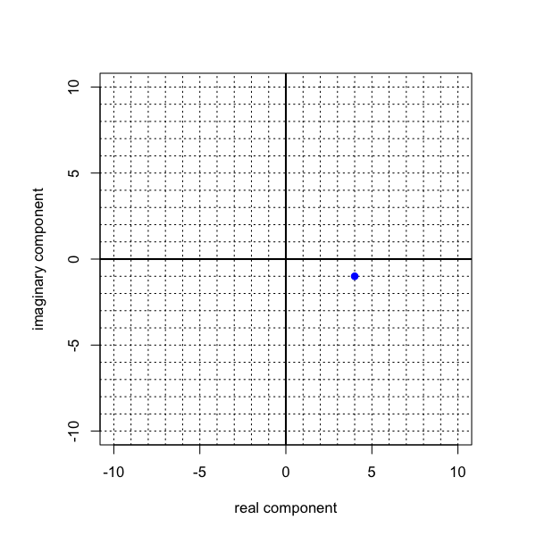

    Please **write the value of $z_1$** (in rectangular form: $a+bi$).

    *Type your answer precisely, with no spaces, using digits, “-”, “+”, and “i”. If the real term is nonzero, put it first. If either component is zero, do not include that term. If both components are zero, type “0” without the quotes. Instead of writing “1i” or “-1i” just write “i” or “-i”.*

#### Solution

#### Question

40. Let $z_1$ be a complex number with integer components. It is graphed on a [complex plane](https://en.wikipedia.org/wiki/Complex_plane) below.

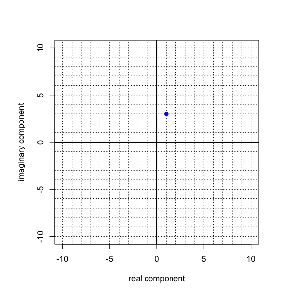

    Please **write the value of $z_1$** (in rectangular form: $a+bi$).

    *Type your answer precisely, with no spaces, using digits, “-”, “+”, and “i”. If the real term is nonzero, put it first. If either component is zero, do not include that term. If both components are zero, type “0” without the quotes. Instead of writing “1i” or “-1i” just write “i” or “-i”.*

#### Solution

#### Question

41. Find solutions to the polynomial equation below.
    $$z^{6} + 9 z^{5} - z^{4} - 221 z^{3} - 472 z^{2} + 1260 z + 3600=0$$

    To find the solutions, I’d recommend using [this website](https://samuelj.li/complex-function-plotter/#z%5E6%2B9*z%5E5-z%5E4-221*z%5E3-472*z%5E2%2B1260*z%2B3600), which uses [domain coloring](https://en.wikipedia.org/wiki/Domain_coloring) to visualize the solutions. By default the solutions will appear as the center of concentric rings.
    1. -3
    2. -4-2i
    3. -4-4i
    4. -4+2i
    5. -4+4i
    6. -5
    7. 0
    8. 1
    9. 3
    10. 4

#### Solution

#### Question

42. Find solutions to the polynomial equation below.
    $$z^{6} - 11 z^{5} + 45 z^{4} - 71 z^{3} + 44 z^{2} - 60 z=0$$

    To find the solutions, I’d recommend using [this website](https://samuelj.li/complex-function-plotter/#z%5E6-11*z%5E5%2B45*z%5E4-71*z%5E3%2B44*z%5E2-60*z), which uses [domain coloring](https://en.wikipedia.org/wiki/Domain_coloring) to visualize the solutions. By default the solutions will appear as the center of concentric rings.
    1. -1
    2. -3
    3. -5
    4. -i
    5. 0
    6. 3
    7. 4-2i
    8. 4+2i
    9. 5
    10. i

#### Solution

#### Question

43. Find solutions to the polynomial equation below.
    $$z^{7} + 7 z^{6} - 26 z^{5} - 288 z^{4} + 245 z^{3} + 4151 z^{2} - 5500 z - 33150=0$$

    To find the solutions, I’d recommend using [this website](https://samuelj.li/complex-function-plotter/#z%5E7%2B7*z%5E6-26*z%5E5-288*z%5E4%2B245*z%5E3%2B4151*z%5E2-5500*z-33150), which uses [domain coloring](https://en.wikipedia.org/wiki/Domain_coloring) to visualize the solutions. By default the solutions will appear as the center of concentric rings.
    1. -2
    2. -3
    3. -5
    4. -5-3i
    5. -5-5i
    6. -5+3i
    7. -5+5i
    8. 3-2i
    9. 3+2i
    10. 5

#### Solution

#### Question

44. Find solutions to the polynomial equation below.
    $$z^{4} + 9 z^{3} + 10 z^{2} - 86 z - 156=0$$

    To find the solutions, I’d recommend using [this website](https://samuelj.li/complex-function-plotter/#z%5E4%2B9*z%5E3%2B10*z%5E2-86*z-156), which uses [domain coloring](https://en.wikipedia.org/wiki/Domain_coloring) to visualize the solutions. By default the solutions will appear as the center of concentric rings.
    1. -2
    2. -4
    3. -5
    4. -5-i
    5. -5+i
    6. 1-4i
    7. 1+4i
    8. 2
    9. 3
    10. 4

#### Solution

#### Question

45. Find solutions to the polynomial equation below.
    $$z^{6} - 10 z^{5} + 18 z^{4} + 108 z^{3} - 403 z^{2} - 122 z + 1560=0$$

    To find the solutions, I’d recommend using [this website](https://samuelj.li/complex-function-plotter/#z%5E6-10*z%5E5%2B18*z%5E4%2B108*z%5E3-403*z%5E2-122*z%2B1560), which uses [domain coloring](https://en.wikipedia.org/wiki/Domain_coloring) to visualize the solutions. By default the solutions will appear as the center of concentric rings.
    1. -2
    2. -3
    3. -4
    4. -5
    5. 2
    6. 3
    7. 3-2i
    8. 3+2i
    9. 4
    10. 5

#### Solution

#### Question

46. Find solutions to the polynomial equation below.
    $$z^{5} - 3 z^{4} - 18 z^{3} + 90 z^{2} - 100 z=0$$

    To find the solutions, I’d recommend using [this website](https://samuelj.li/complex-function-plotter/#z%5E5-3*z%5E4-18*z%5E3%2B90*z%5E2-100*z), which uses [domain coloring](https://en.wikipedia.org/wiki/Domain_coloring) to visualize the solutions. By default the solutions will appear as the center of concentric rings.
    1. -1
    2. -3
    3. -5
    4. 0
    5. 2
    6. 3-i
    7. 3+i
    8. 4
    9. 4-3i
    10. 4+3i

#### Solution

#### Question

47. Find solutions to the polynomial equation below.
    $$z^{7} - 7 z^{6} - 14 z^{5} + 180 z^{4} + 19 z^{3} - 1213 z^{2} - 446 z + 3480=0$$

    To find the solutions, I’d recommend using [this website](https://samuelj.li/complex-function-plotter/#z%5E7-7*z%5E6-14*z%5E5%2B180*z%5E4%2B19*z%5E3-1213*z%5E2-446*z%2B3480), which uses [domain coloring](https://en.wikipedia.org/wiki/Domain_coloring) to visualize the solutions. By default the solutions will appear as the center of concentric rings.
    1. -1
    2. -2
    3. -2-i
    4. -2+i
    5. -4
    6. 1
    7. 2
    8. 3
    9. 5-2i
    10. 5+2i

#### Solution

#### Question

48. Find solutions to the polynomial equation below.
    $$z^{7} + 13 z^{6} + 52 z^{5} - 38 z^{4} - 880 z^{3} - 2600 z^{2} - 3328 z - 1920=0$$

    To find the solutions, I’d recommend using [this website](https://samuelj.li/complex-function-plotter/#z%5E7%2B13*z%5E6%2B52*z%5E5-38*z%5E4-880*z%5E3-2600*z%5E2-3328*z-1920), which uses [domain coloring](https://en.wikipedia.org/wiki/Domain_coloring) to visualize the solutions. By default the solutions will appear as the center of concentric rings.
    1. -1-i
    2. -1+i
    3. -3
    4. -4
    5. -4-2i
    6. -4+2i
    7. -5
    8. 1
    9. 3
    10. 4

#### Solution

#### Question

49. Find solutions to the polynomial equation below.
    $$z^{4} + 7 z^{3} + 13 z^{2} - 23 z - 78=0$$

    To find the solutions, I’d recommend using [this website](https://samuelj.li/complex-function-plotter/#z%5E4%2B7*z%5E3%2B13*z%5E2-23*z-78), which uses [domain coloring](https://en.wikipedia.org/wiki/Domain_coloring) to visualize the solutions. By default the solutions will appear as the center of concentric rings.
    1. -1
    2. -2-i
    3. -2+i
    4. -3
    5. -3-2i
    6. -3+2i
    7. -4-4i
    8. -4+4i
    9. 0
    10. 2

#### Solution

#### Question

50. Find solutions to the polynomial equation below.
    $$z^{5} + 6 z^{4} + 2 z^{3} - 96 z^{2} - 288 z=0$$

    To find the solutions, I’d recommend using [this website](https://samuelj.li/complex-function-plotter/#z%5E5%2B6*z%5E4%2B2*z%5E3-96*z%5E2-288*z), which uses [domain coloring](https://en.wikipedia.org/wiki/Domain_coloring) to visualize the solutions. By default the solutions will appear as the center of concentric rings.
    1. -1-4i
    2. -1+4i
    3. -3-3i
    4. -3+3i
    5. -4
    6. 0
    7. 2
    8. 4
    9. 5-2i
    10. 5+2i

#### Solution